# Network

## Introduction

Hello again. In this exercise we are going to

1. use pre-trained model for classification,
2. calculate saliency of the image - what regions the classification decision is most sensitive to,
3. create fooling images (called adversarial examples) for neural networks.

We are going to use ResNet-50 model included with Keras. For more information about the model see [this paper](https://arxiv.org/abs/1512.03385).

```python
from keras.applications.resnet50 import ResNet50, preprocess_input, decode_predictions
from keras.preprocessing import image
from keras.models import Model
import keras.backend as K
import numpy as np
import matplotlib.pyplot as plt
%matplotlib inline
```

### Classification using pre-trained model

Keras makes it really easy to make use of pretrained models. For list of currently supported image classification models see [Keras documentation](https://keras.io/applications/).

```python
import ssl
ssl._create_default_https_context = ssl._create_unverified_context

model = ResNet50(weights='imagenet')
model.summary()
```

```
Downloading data from https://github.com/fchollet/deep-learning-models/releases/download/v0.2/resnet50_weights_tf_dim_ordering_tf_kernels.h5
Model: "resnet50"
__________________________________________________________________________________________________
Layer (type)                    Output Shape         Param #     Connected to
==================================================================================================
input_2 (InputLayer)            (None, 224, 224, 3)  0
__________________________________________________________________________________________________
conv1_pad (ZeroPadding2D)       (None, 230, 230, 3)  0           input_2[0][0]
__________________________________________________________________________________________________
conv1 (Conv2D)                  (None, 112, 112, 64) 9472        conv1_pad[0][0]
__________________________________________________________________________________________________
bn_conv1 (BatchNormalization)   (None, 112, 112, 64) 256         conv1[0][0]
__________________________________________________________________________________________________
activation_50 (Activation)      (None, 112, 112, 64) 0           bn_conv1[0][0]
__________________________________________________________________________________________________
pool1_pad (ZeroPadding2D)       (None, 114, 114, 64) 0           activation_50[0][0]
__________________________________________________________________________________________________
max_pooling2d_2 (MaxPooling2D)  (None, 56, 56, 64)   0           pool1_pad[0][0]
__________________________________________________________________________________________________
res2a_branch2a (Conv2D)         (None, 56, 56, 64)   4160        max_pooling2d_2[0][0]
__________________________________________________________________________________________________
bn2a_branch2a (BatchNormalizati (None, 56, 56, 64)   256         res2a_branch2a[0][0]
__________________________________________________________________________________________________
activation_51 (Activation)      (None, 56, 56, 64)   0           bn2a_branch2a[0][0]
__________________________________________________________________________________________________
res2a_branch2b (Conv2D)         (None, 56, 56, 64)   36928       activation_51[0][0]
__________________________________________________________________________________________________
bn2a_branch2b (BatchNormalizati (None, 56, 56, 64)   256         res2a_branch2b[0][0]
__________________________________________________________________________________________________
activation_52 (Activation)      (None, 56, 56, 64)   0           bn2a_branch2b[0][0]
__________________________________________________________________________________________________
res2a_branch2c (Conv2D)         (None, 56, 56, 256)  16640       activation_52[0][0]
__________________________________________________________________________________________________
res2a_branch1 (Conv2D)          (None, 56, 56, 256)  16640       max_pooling2d_2[0][0]
__________________________________________________________________________________________________
bn2a_branch2c (BatchNormalizati (None, 56, 56, 256)  1024        res2a_branch2c[0][0]
__________________________________________________________________________________________________
bn2a_branch1 (BatchNormalizatio (None, 56, 56, 256)  1024        res2a_branch1[0][0]
__________________________________________________________________________________________________
add_17 (Add)                    (None, 56, 56, 256)  0           bn2a_branch2c[0][0]
```

[output cut: 324 more lines]

```
bn5c_branch2c (BatchNormalizati (None, 7, 7, 2048)   8192        res5c_branch2c[0][0]
__________________________________________________________________________________________________
add_32 (Add)                    (None, 7, 7, 2048)   0           bn5c_branch2c[0][0]
                                                                 activation_95[0][0]
__________________________________________________________________________________________________
activation_98 (Activation)      (None, 7, 7, 2048)   0           add_32[0][0]
__________________________________________________________________________________________________
avg_pool (GlobalAveragePooling2 (None, 2048)         0           activation_98[0][0]
__________________________________________________________________________________________________
fc1000 (Dense)                  (None, 1000)         2049000     avg_pool[0][0]
==================================================================================================
Total params: 25,636,712
Trainable params: 25,583,592
Non-trainable params: 53,120
__________________________________________________________________________________________________
```

**Task 3.1 (1.5pts):** What is the number of parameters? What is the number of weight layers? Where ResNet gets its name?

**Your answer:**

- The number of parameters = 25,636,712
- The number of weight layers = 53
- ResNet means Residual Network

Let's load the image that we will be working with.

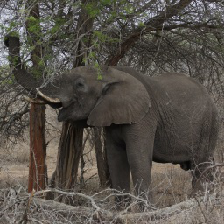

```python
img = image.load_img('elephant.jpg', target_size=(224, 224))
img
```

```python
# convert image to array
x = image.img_to_array(img)
# add batch axis
x = x[np.newaxis]
# subtract mean from the image
x = preprocess_input(x)
x.shape
```

```
(1, 224, 224, 3)
```

Pass the image through the network and read out the predictions.

```python
probs = model.predict(x)
decode_predictions(probs, top=5)
```

```
[[('n02504458', 'African_elephant', 0.49034452),
  ('n01871265', 'tusker', 0.40343028),
  ('n02504013', 'Indian_elephant', 0.106020875),
  ('n02397096', 'warthog', 4.5559427e-05),
  ('n02408429', 'water_buffalo', 1.9427402e-05)]]
```

Fetch the label and name of the class.

```python
from keras_applications.imagenet_utils import CLASS_INDEX

def label2str(label):
    return CLASS_INDEX[str(label)][1]

label = np.argmax(probs)
print(label, label2str(label))
```

```
386 African_elephant
```

### Saliency maps

For saliency maps we need to calculate gradient of the input image with respect to the class probability (or score). Basically this tells us, which part of the image the model is most sensitive to.

```python
# produces computational graph for calculating gradients of correct class probability w.r.t. input image
grads = K.gradients(model.output[0, label], model.input)
# creates a wrapper around computational graph, so that we can use it as a function
grads_saliency = K.function([model.input, K.learning_phase()], grads)
```

```python
# the second parameter in list is 1 for training phase, 0 for test phase
x_grads = grads_saliency([x, 0])[0]
x_grads.shape
```

```
(1, 224, 224, 3)
```

**Task 3.2 (0.5pts):** which layers behave differently in train/test phase?

**Your answer:** The convolutional and corresponding activation layers

**Task 3.3 (1pt):** we are interested in sensitivity to pixel locations, ignoring the sign and color channels.

```python
##############################################################################
# TODO: Take absolute values of the gradients and maximum over channels.     #
##############################################################################
# Set the axis value = 3 to get the max values from all channels
x_saliency = np.max(np.abs(x_grads), axis = (3))
##############################################################################
#                             END OF YOUR CODE                               #
##############################################################################
assert x_saliency.shape == x.shape[:3]
```

```python
# helper function for denormalizing images
x_mean = np.array([103.939, 116.779, 123.68])
def decode_image(x):
    return np.clip((x + x_mean)[..., ::-1], 0, 255).astype(np.uint8)
```

```
(-0.5, 223.5, 223.5, -0.5)
```

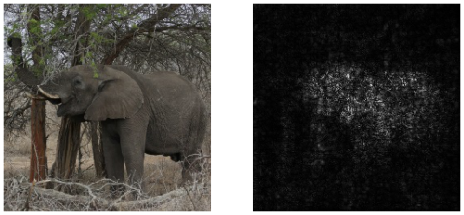

```python
plt.figure(figsize=(16,8))

plt.subplot(1,2,1)
plt.imshow(decode_image(x[0]))
plt.axis('off')

plt.subplot(1,2,2)
plt.imshow(x_saliency[0], cmap='gray')
plt.axis('off')
```

**Task 3.4 (1pt):** what parts of the image is the classifier sensitive to?

**Your answer:** It sensitive to certain colors of the image that very similar to the elephant's skin

### Fooling the network

Now we are going to create a picture that looks very much like an elephant, but the network classifies it as something completely irrelevant. Being easily fooled is well known problem of neural networks and is active area of research. For more information and references see [this blog post](https://blog.openai.com/adversarial-example-research/).

For this we are going to calculate the gradients of target class probablity w.r.t. the input image and perform gradient ascent, i.e. change the picture so that the target class has the highest probability.

```python
# for fun we choose paper towel :)
target = 700
print(target, label2str(target))
```

```
700 paper_towel
```

```python
# gradients of target class w.r.t. the input image
grads = K.gradients(model.output[0, target], model.input)
# inputs are image and learning phase, outputs are probabilities and gradients
grads_fool = K.function([model.input, K.learning_phase()], [model.output] + grads)
```

**Task 3.5 (4pts):** Implement gradient ascent to change the input image so that the target class probability increases

```python
learning_rate = 10
x_fake = x.copy()
for i in range(100):
    preds, x_grads = grads_fool([x_fake, 0])

    new_label = np.argmax(preds)

    print(i, ':', "current class:", label2str(new_label), "(%.02f)" % preds[0, new_label], "target class:", label2str(target), "(%.02f)" % preds[0, target])
    if new_label == target:
        break

    ##############################################################################
    # TODO: Implement gradient ascent to change the input image so that the      #
    #       target class probability increases. NB! You should normalize the     #
    #       gradients using L2 norm before multiplying them with learning rate   #
    #       and adding to the input image.                                       #
    ##############################################################################
    # Using scipy linear algebra to normalize the gradients
    x_fake += learning_rate * (x_grads / np.linalg.norm(x_grads))
    ##############################################################################
    #                             END OF YOUR CODE                               #
    ##############################################################################
```

```
0 : current class: African_elephant (0.49) target class: paper_towel (0.00)
1 : current class: African_elephant (0.44) target class: paper_towel (0.00)
2 : current class: tusker (0.44) target class: paper_towel (0.00)
3 : current class: tusker (0.45) target class: paper_towel (0.00)
4 : current class: tusker (0.45) target class: paper_towel (0.00)
5 : current class: tusker (0.45) target class: paper_towel (0.00)
6 : current class: tusker (0.44) target class: paper_towel (0.00)
7 : current class: tusker (0.43) target class: paper_towel (0.00)
8 : current class: tusker (0.41) target class: paper_towel (0.00)
9 : current class: tusker (0.38) target class: paper_towel (0.00)
10 : current class: tusker (0.35) target class: paper_towel (0.00)
11 : current class: tusker (0.31) target class: paper_towel (0.00)
12 : current class: tusker (0.28) target class: paper_towel (0.00)
13 : current class: tusker (0.24) target class: paper_towel (0.00)
14 : current class: tusker (0.21) target class: paper_towel (0.00)
```

[output cut: 19 more lines]

```
(-0.5, 223.5, 223.5, -0.5)
```

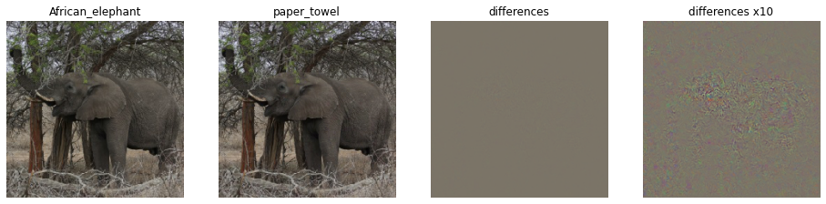

```python
plt.figure(figsize=(16,8))

plt.subplot(1,4,1)
plt.imshow(decode_image(x[0]))
plt.title(label2str(label))
plt.axis('off')

plt.subplot(1,4,2)
plt.imshow(decode_image(x_fake[0]))
plt.title(label2str(target))
plt.axis('off')

plt.subplot(1,4,3)
plt.imshow(decode_image((x - x_fake)[0]))
plt.title("differences")
plt.axis('off')

# it's hard to even see the diffferences, so let's amplify them
plt.subplot(1,4,4)
plt.imshow(decode_image((x - x_fake)[0] * 10))
plt.title("differences x10")
plt.axis('off')
```

**Task 3.6 (2pts):** what are the potential implications of adversarial examples?

**Your answer:**

- It was important to understand how the network interprets the data and some potential attackers can confuse it to making mistakes.
- It will become helpful to close the gap between designing network that perform in the intended way against what should they actually behave